# Resource Tracking Descriptive Verification

Emily Linebarger

April 12, 2019

# BUDGETS AND EXPENDITURES

## Plot data

Visualize the budget data by grant and year. Focus only on current grant first.

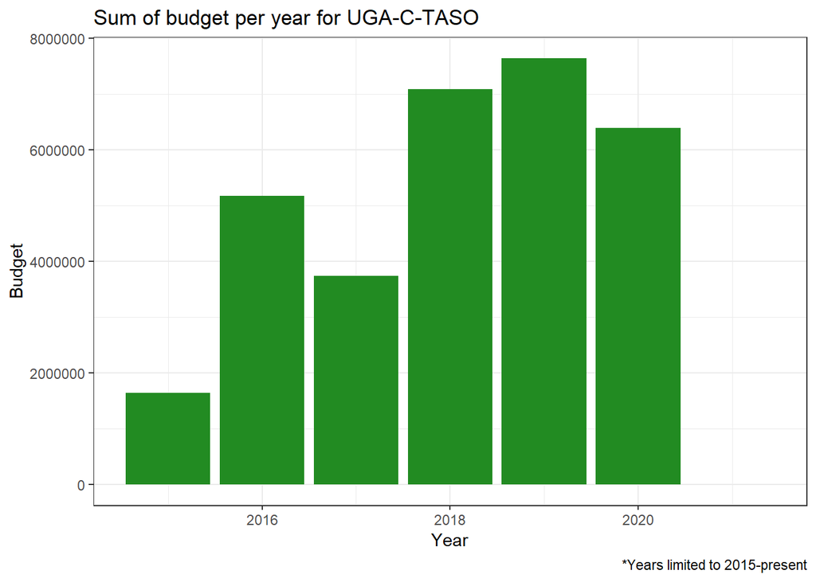

```
##         grant year loc_name  budget
## 1: UGA-C-TASO 2015      uga 1640564
## 2: UGA-C-TASO 2016      uga 5172553
## 3: UGA-C-TASO 2017      uga 3736113
## 4: UGA-C-TASO 2018      uga 7079861
## 5: UGA-C-TASO 2019      uga 7638925
## 6: UGA-C-TASO 2020      uga 6387360
## 7: UGA-C-TASO 2021      uga       0
```

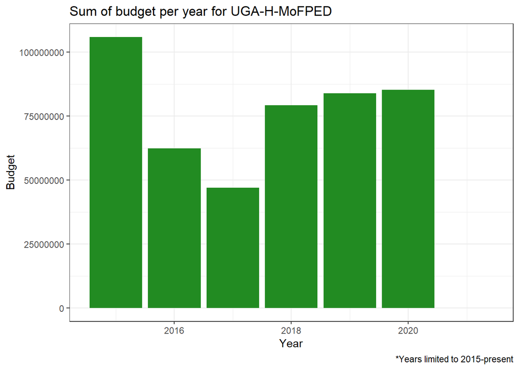

```
##           grant year loc_name    budget
## 1: UGA-H-MoFPED 2015      uga 105898132
## 2: UGA-H-MoFPED 2016      uga  62402151
## 3: UGA-H-MoFPED 2017      uga  46958215
## 4: UGA-H-MoFPED 2018      uga  79198651
## 5: UGA-H-MoFPED 2019      uga  83826699
## 6: UGA-H-MoFPED 2020      uga  85186776
## 7: UGA-H-MoFPED 2021      uga         0
```

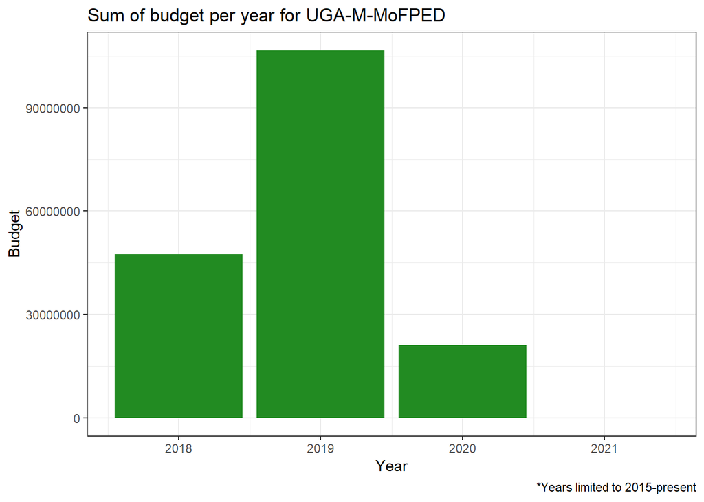

```
##           grant year loc_name    budget
## 1: UGA-M-MoFPED 2018      uga  47530745
## 2: UGA-M-MoFPED 2019      uga 106697396
## 3: UGA-M-MoFPED 2020      uga  21082225
## 4: UGA-M-MoFPED 2021      uga         0
```

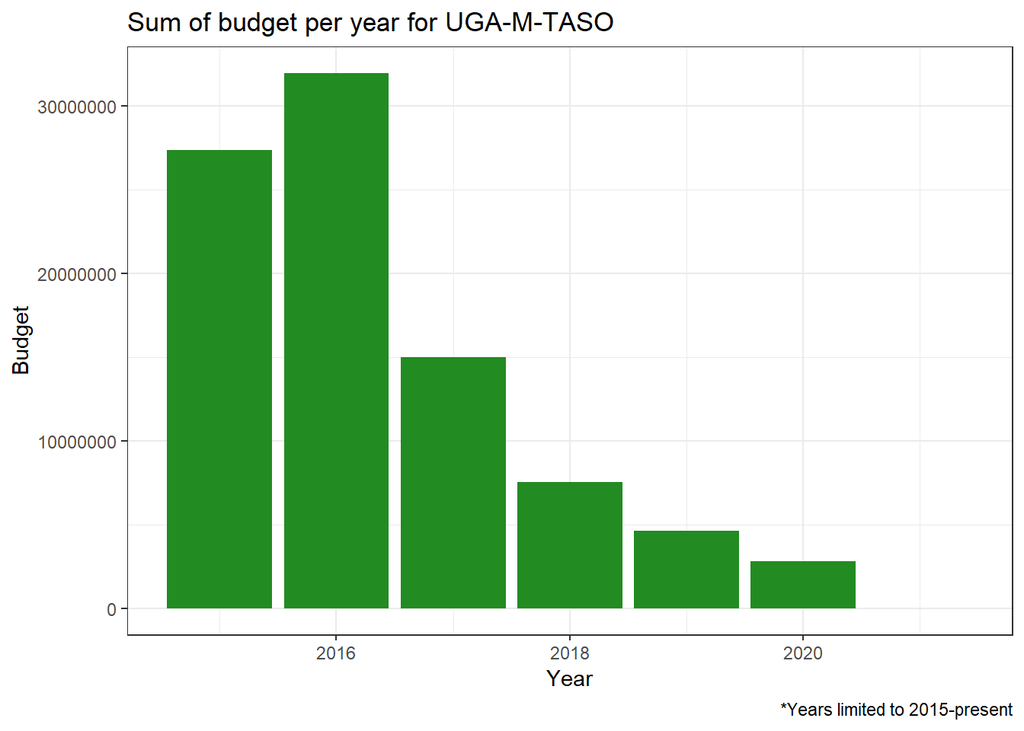

```
##         grant year loc_name   budget
## 1: UGA-M-TASO 2015      uga 27372404
## 2: UGA-M-TASO 2016      uga 31954069
## 3: UGA-M-TASO 2017      uga 14985053
## 4: UGA-M-TASO 2018      uga  7530061
## 5: UGA-M-TASO 2019      uga  4620320
## 6: UGA-M-TASO 2020      uga  2819152
## 7: UGA-M-TASO 2021      uga        0
```

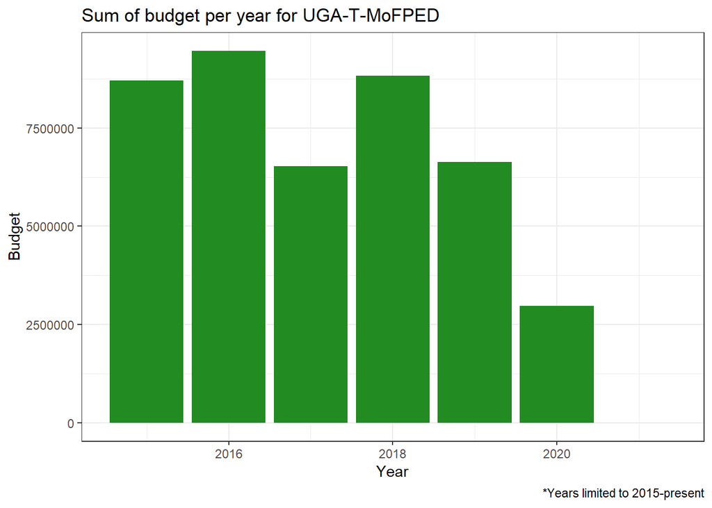

```
##            grant year loc_name   budget
##  1: UGA-T-MoFPED 2015      uga  8705167
##  2: UGA-T-MoFPED 2016      uga  9465503
##  3: UGA-T-MoFPED 2017      uga  6527624
##  4: UGA-T-MoFPED 2018      uga  8835353
##  5: UGA-T-MoFPED 2019      uga  6633157
##  6: UGA-T-MoFPED 2020      uga  2976516
##  7: UGA-T-MoFPED 2021      uga        0
##  8: UGA-T-MoFPED 2012      uga 12788525
##  9: UGA-T-MoFPED 2013      uga  3470698
## 10: UGA-T-MoFPED 2014      uga  4252560
```

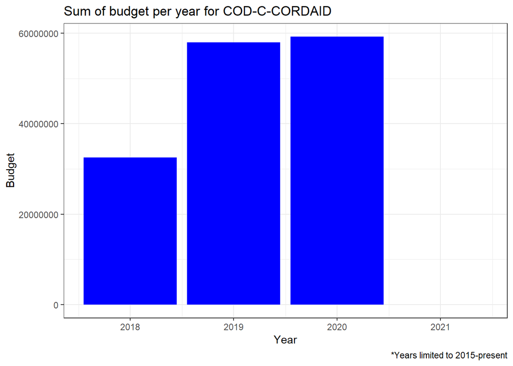

```
##            grant year loc_name   budget
## 1: COD-C-CORDAID 2018      cod 32523926
## 2: COD-C-CORDAID 2019      cod 57950135
## 3: COD-C-CORDAID 2020      cod 59268197
## 4: COD-C-CORDAID 2021      cod        0
```

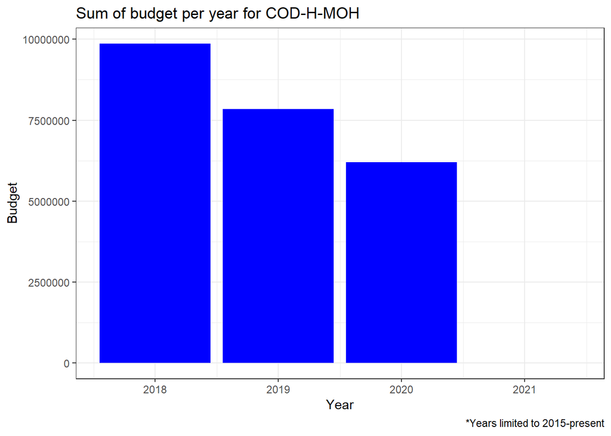

```
##        grant year loc_name  budget
## 1: COD-H-MOH 2018      cod 9868071
## 2: COD-H-MOH 2019      cod 7850787
## 3: COD-H-MOH 2020      cod 6194667
## 4: COD-H-MOH 2021      cod       0
```

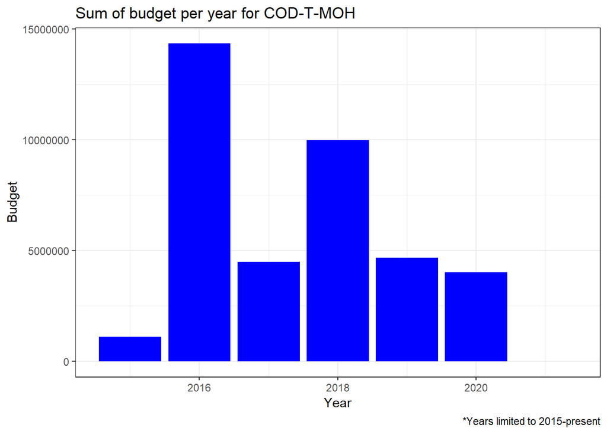

```
##        grant year loc_name   budget
## 1: COD-T-MOH 2015      cod  1089781
## 2: COD-T-MOH 2016      cod 14351576
## 3: COD-T-MOH 2017      cod  4480726
## 4: COD-T-MOH 2018      cod  9988893
## 5: COD-T-MOH 2019      cod  4670992
## 6: COD-T-MOH 2020      cod  4019409
## 7: COD-T-MOH 2021      cod        0
```

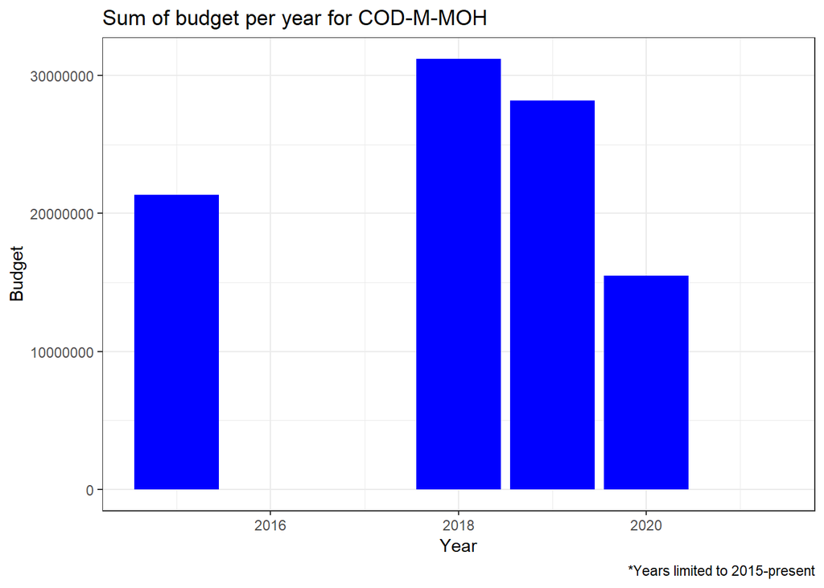

```
##        grant year loc_name   budget
## 1: COD-M-MOH 2018      cod 31222301
## 2: COD-M-MOH 2019      cod 28209536
## 3: COD-M-MOH 2020      cod 15476776
## 4: COD-M-MOH 2021      cod        0
## 5: COD-M-MOH 2015      cod 21358079
```

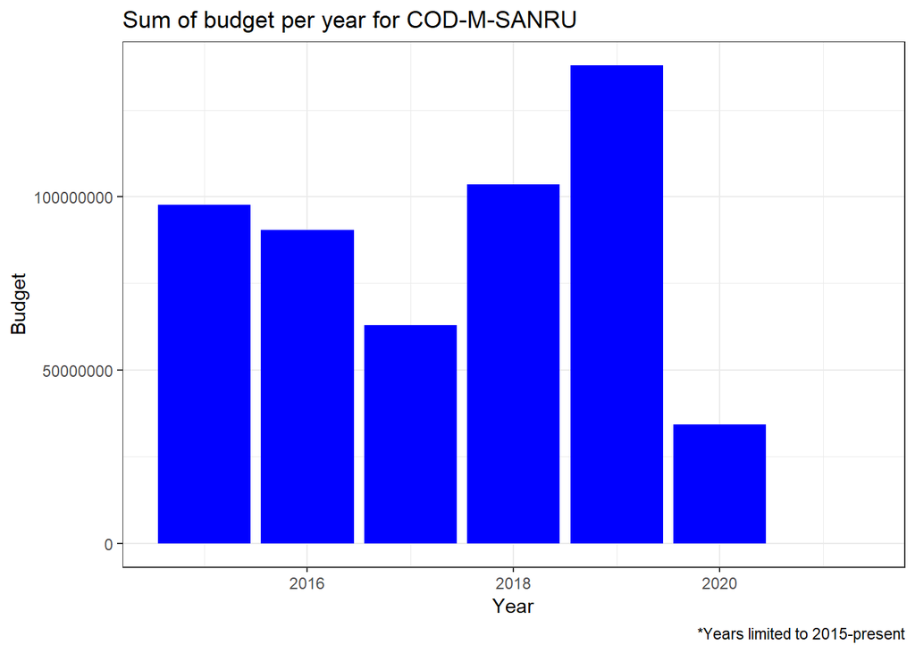

```
##           grant year loc_name    budget
##  1: COD-M-SANRU 2015      cod  97577339
##  2: COD-M-SANRU 2016      cod  90379095
##  3: COD-M-SANRU 2017      cod  62983147
##  4: COD-M-SANRU 2018      cod 103534340
##  5: COD-M-SANRU 2019      cod 137901382
##  6: COD-M-SANRU 2020      cod  34281713
##  7: COD-M-SANRU 2021      cod         0
##  8: COD-M-SANRU 2012      cod  27587797
##  9: COD-M-SANRU 2013      cod  68218018
## 10: COD-M-SANRU 2014      cod  43710404
```

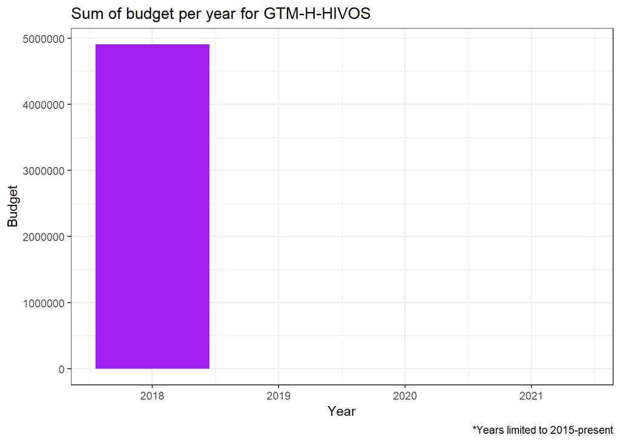

```
##          grant year loc_name  budget
## 1: GTM-H-HIVOS 2018      gtm 4909342
## 2: GTM-H-HIVOS 2019      gtm       0
## 3: GTM-H-HIVOS 2020      gtm       0
## 4: GTM-H-HIVOS 2021      gtm       0
```

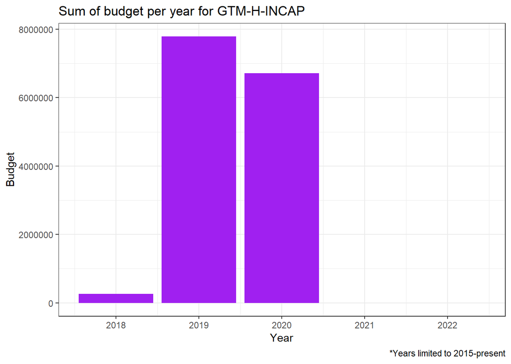

```
##          grant year loc_name  budget
## 1: GTM-H-INCAP 2018      gtm  261480
## 2: GTM-H-INCAP 2019      gtm 7789487
## 3: GTM-H-INCAP 2020      gtm 6710251
## 4: GTM-H-INCAP 2021      gtm       0
## 5: GTM-H-INCAP 2022      gtm       0
```

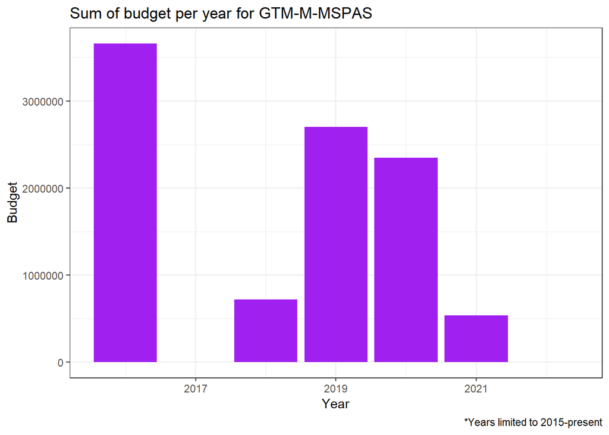

```
##          grant year loc_name  budget
## 1: GTM-M-MSPAS 2016      gtm 3659506
## 2: GTM-M-MSPAS 2018      gtm  716023
## 3: GTM-M-MSPAS 2019      gtm 2702325
## 4: GTM-M-MSPAS 2020      gtm 2346046
## 5: GTM-M-MSPAS 2021      gtm  534258
## 6: GTM-M-MSPAS 2022      gtm       0
```

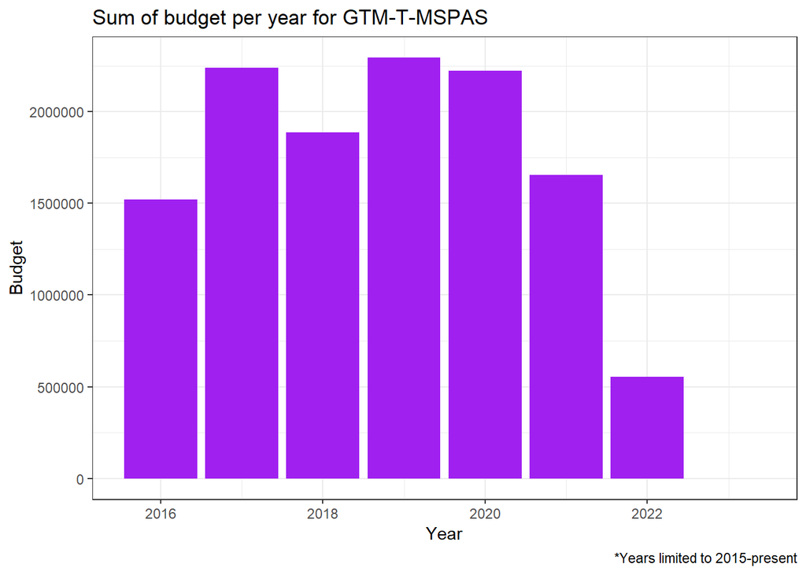

```
##          grant year loc_name  budget
## 1: GTM-T-MSPAS 2016      gtm 1520232
## 2: GTM-T-MSPAS 2017      gtm 2240111
## 3: GTM-T-MSPAS 2018      gtm 1885886
## 4: GTM-T-MSPAS 2019      gtm 2294591
## 5: GTM-T-MSPAS 2020      gtm 2223766
## 6: GTM-T-MSPAS 2021      gtm 1652640
## 7: GTM-T-MSPAS 2022      gtm  554927
## 8: GTM-T-MSPAS 2023      gtm       0
```

## Visualize by disease and country

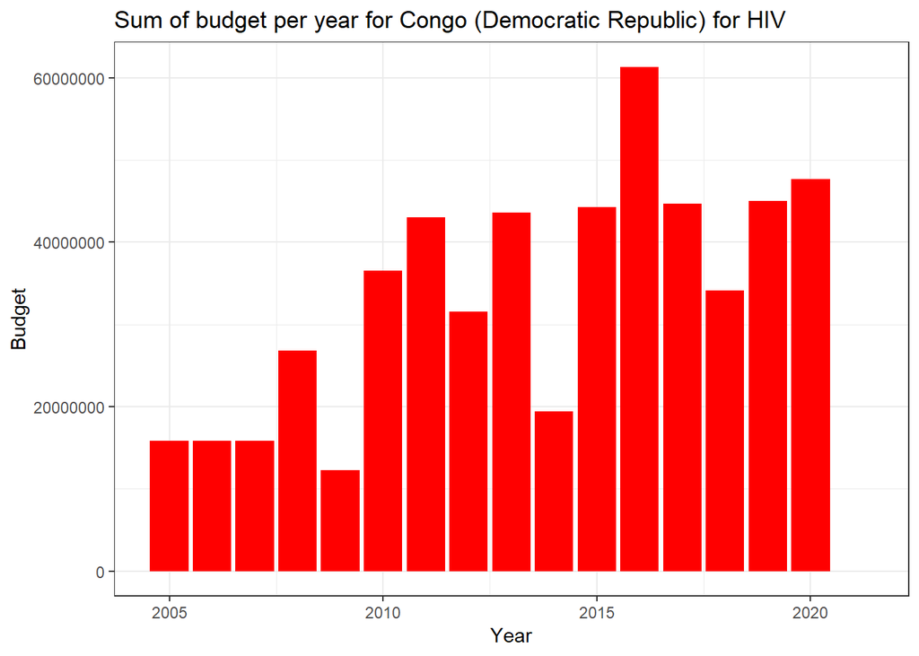

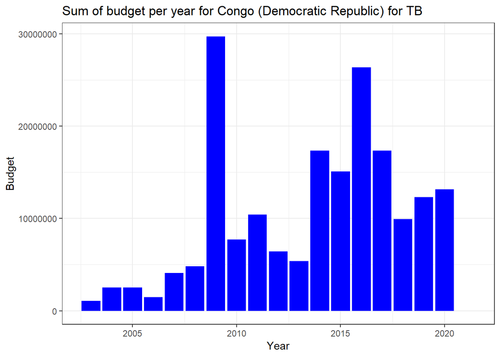

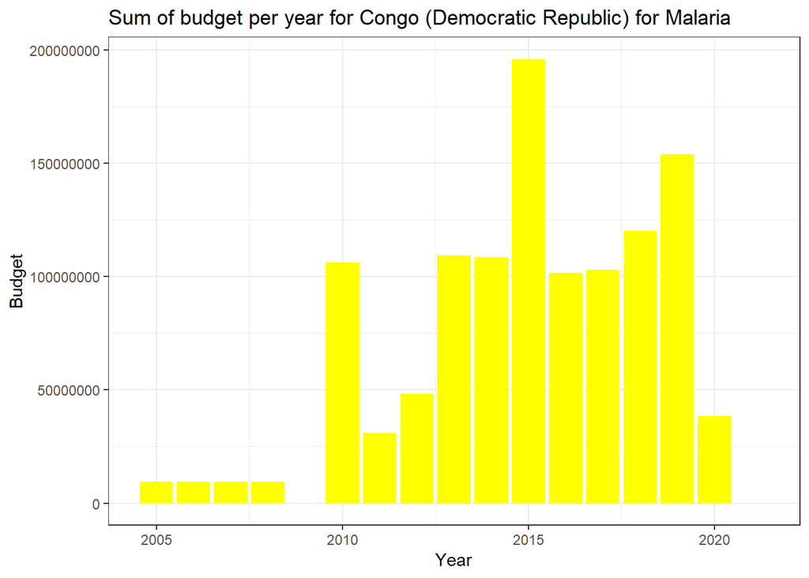

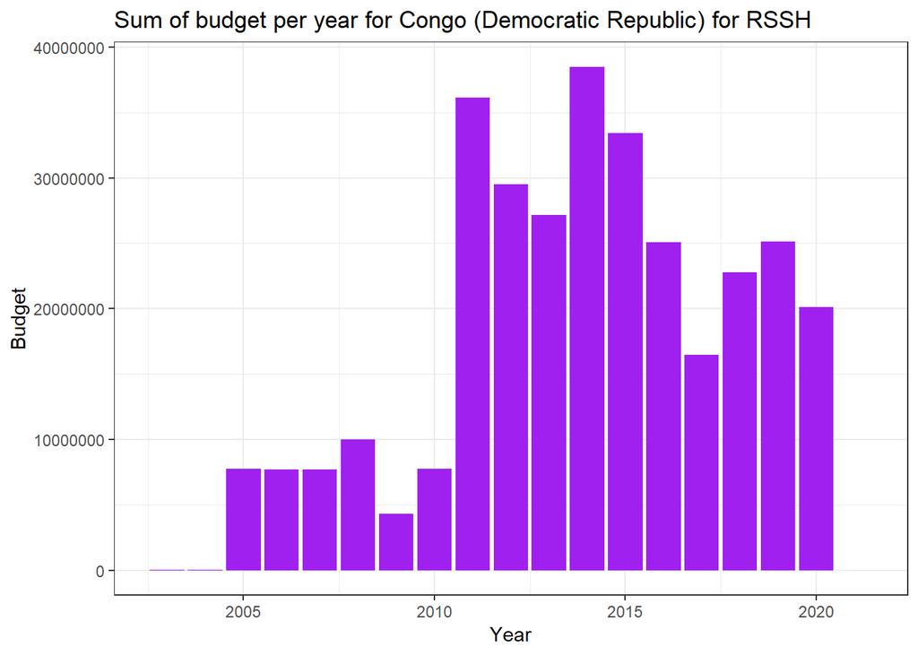

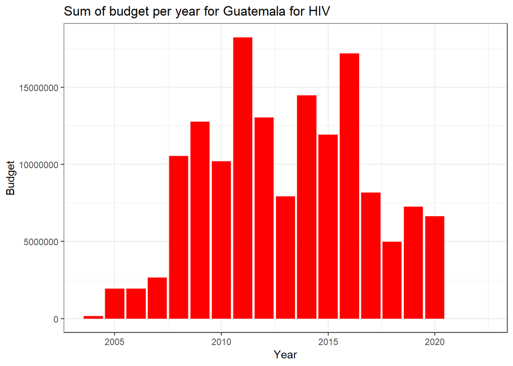

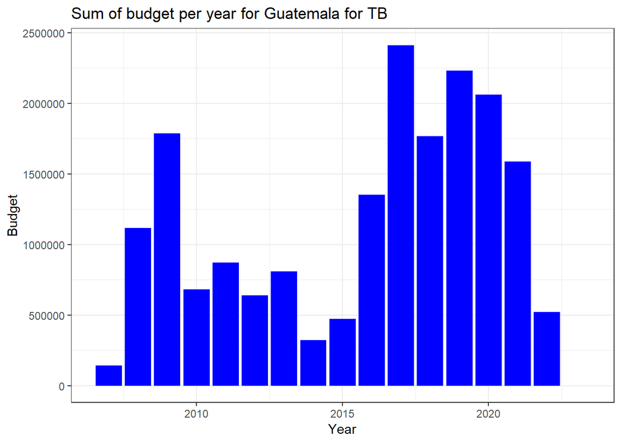

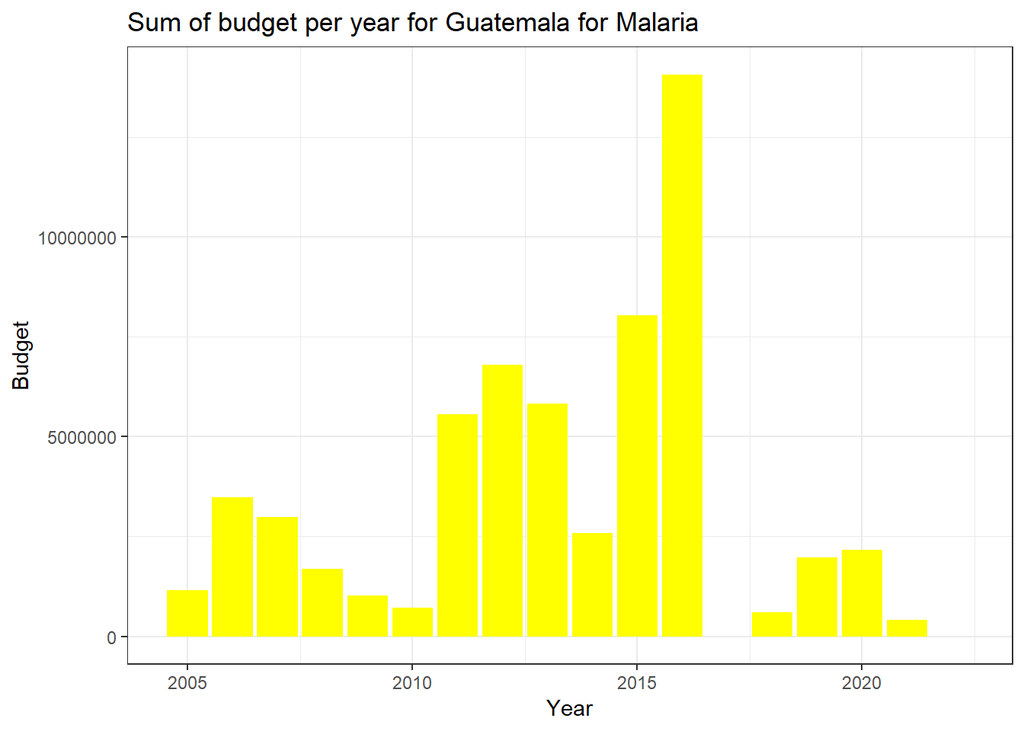

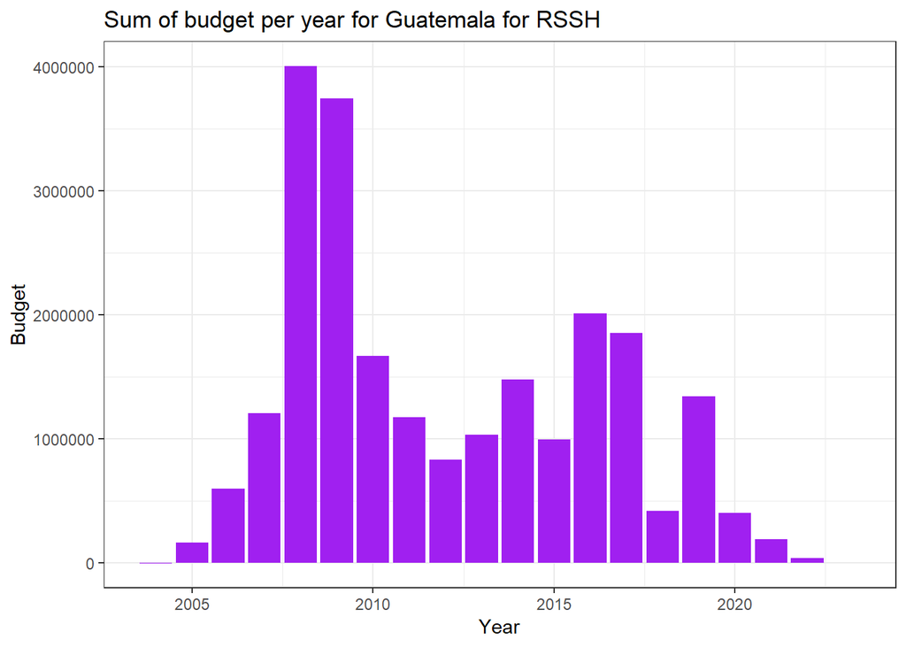

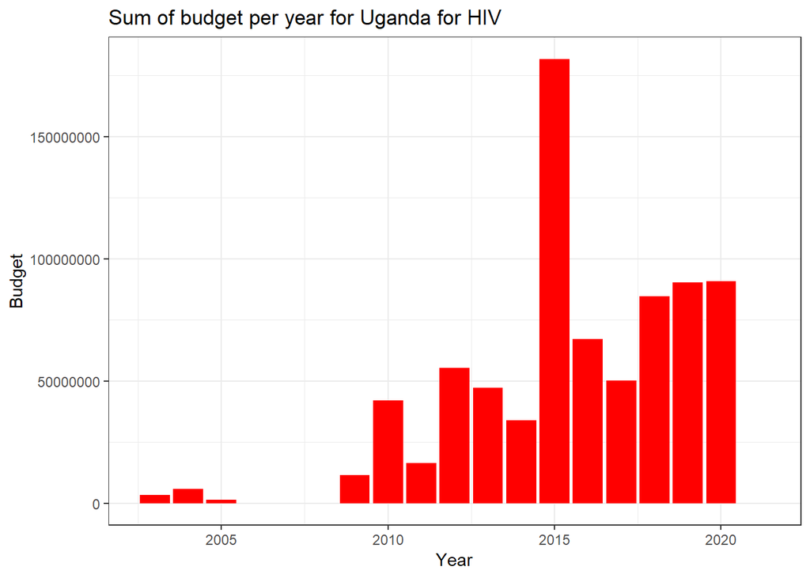

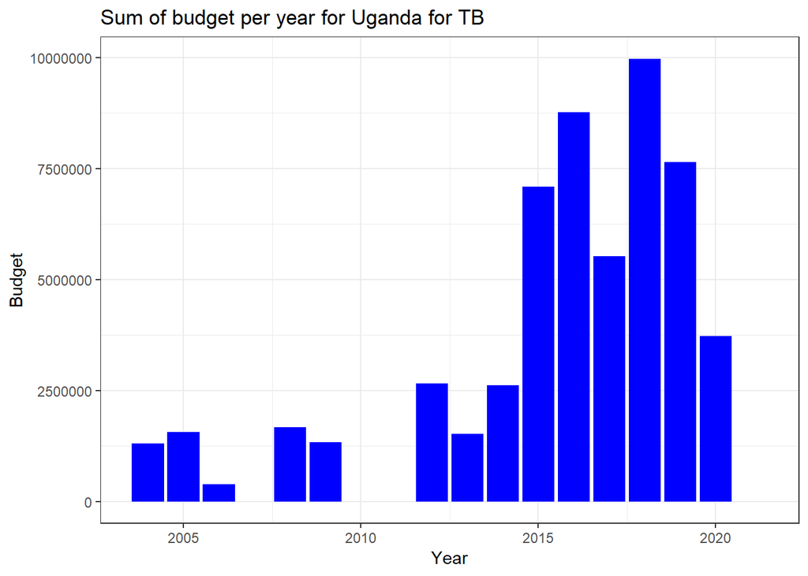

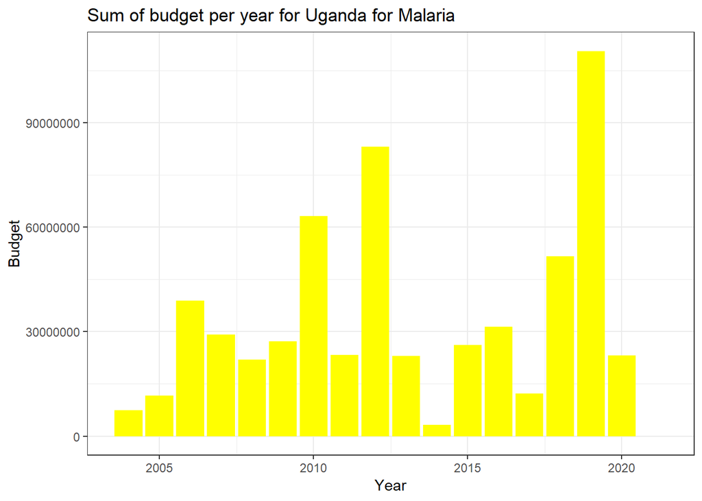

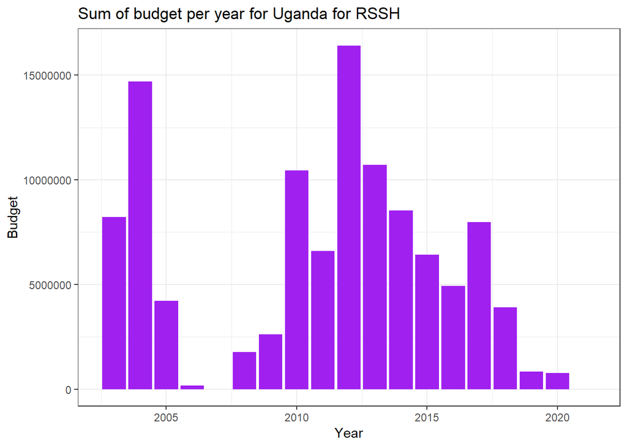

[4 more figures not shown]

## Review variables

Are the formats of the variables what you expect?

Check specific variable values

Are you returning only expected values for ‘disease’ column in budgets?: TRUE, TRUE, TRUE, TRUE Are you returning only expected values for ‘disease’ column in PUDRs?: TRUE, TRUE, TRUE, TRUE

Is your start date variable a date in budgets? TRUE What about your end date variable? FALSE What’s the range of start date? 2003-04-01, 2023-04-01

Is your start date variable a date in PUDRs? TRUE What about your end date variable? TRUE What’s the range of start date? 2003-04-01, 2018-10-01

What values do you have for language, loc_name, and country? For budgets:

```
## [1] "fr"  "eng" "esp" NA
```

```
## [1] "cod" "gtm" "uga" "sen"
```

```
## [1] "Congo (Democratic Republic)" "Guatemala"
## [3] "Uganda"                      "Senegal"
```

For expenditures:

```
## [1] "cod" "gtm" "sen" "uga"
```

Is the ‘current grant’ flag working correctly? Make sure all files are sorted by this boolean correctly.

```
##     current_grant         grant grant_period
##  1:          TRUE COD-C-CORDAID    2018-2020
##  2:          TRUE     COD-H-MOH    2018-2020
##  3:          TRUE     COD-M-MOH    2018-2020
##  4:          TRUE   COD-M-SANRU    2018-2020
##  5:          TRUE     COD-T-MOH    2018-2020
##  6:          TRUE   GTM-H-HIVOS         2018
##  7:          TRUE   GTM-H-INCAP    2018-2020
##  8:          TRUE   GTM-M-MSPAS    2018-2020
##  9:          TRUE   GTM-M-MSPAS    2019-2021
## 10:          TRUE   GTM-T-MSPAS    2016-2019
## 11:          TRUE   GTM-T-MSPAS    2019-2022
## 12:          TRUE    SEN-H-ANCS    2018-2020
## 13:          TRUE    SEN-H-CNLS    2018-2020
## 14:          TRUE    SEN-M-PNLP    2018-2020
## 15:          TRUE     SEN-Z-MOH    2018-2020
## 16:          TRUE    UGA-C-TASO    2018-2020
## 17:          TRUE  UGA-H-MoFPED    2018-2020
## 18:          TRUE  UGA-M-MoFPED    2018-2020
## 19:          TRUE    UGA-M-TASO    2018-2020
## 20:          TRUE  UGA-T-MoFPED    2018-2020
```

```
##     current_grant            grant grant_period
##  1:         FALSE    COD-607-G05-T    2007-2009
##  2:         FALSE    COD-809-G07-M    2010-2012
##  3:         FALSE    COD-810-G08-M    2010-2012
##  4:         FALSE    COD-810-G11-H    2010-2012
##  5:         FALSE    COD-810-G12-H    2010-2012
##  6:         FALSE    COD-H-CORDAID    2012-2017
##  7:         FALSE      COD-H-SANRU    2012-2017
##  8:         FALSE      COD-H-SANRU    2015-2017
##  9:         FALSE        COD-M-MOH    2015-2017
## 10:         FALSE        COD-M-PSI    2015-2017
## 11:         FALSE      COD-M-PSI-X    2012-2014
## 12:         FALSE      COD-M-SANRU    2012-2017
## 13:         FALSE      COD-M-SANRU    2015-2017
## 14:         FALSE    COD-T-CARITAS    2015-2017
```

[output cut: 61 more lines]

Is the ‘grant_disease’ flag working correctly? Make sure that the disease makes sense for the name of the grant. First showing budget and then expenditure.

```
##                grant grant_disease
##  1:    COD-C-CORDAID        hiv/tb
##  2:    COD-H-CORDAID           hiv
##  3:        COD-H-MOH           hiv
##  4:      COD-H-SANRU           hiv
##  5:        COD-M-MOH       malaria
##  6:        COD-M-PSI       malaria
##  7:      COD-M-SANRU       malaria
##  8:    COD-T-CARITAS            tb
##  9:        COD-T-MOH            tb
## 10:      GTM-H-HIVOS           hiv
## 11:      GTM-H-INCAP           hiv
## 12:      GTM-M-MSPAS       malaria
## 13:      GTM-T-MSPAS            tb
## 14:    GUA-311-G05-H           hiv
```

[output cut: 61 more lines]

```
##                grant grant_disease
##  1:    COD-607-G05-T            tb
##  2:    COD-809-G07-M       malaria
##  3:    COD-810-G08-M       malaria
##  4:    COD-810-G11-H           hiv
##  5:    COD-810-G12-H           hiv
##  6:    COD-H-CORDAID           hiv
##  7:      COD-H-SANRU           hiv
##  8:        COD-M-MOH       malaria
##  9:        COD-M-PSI       malaria
## 10:      COD-M-PSI-X       malaria
## 11:      COD-M-SANRU       malaria
## 12:    COD-T-CARITAS            tb
## 13:        COD-T-MOH            tb
## 14:    GTM-304-G01-H           hiv
```

[output cut: 58 more lines]

# ABSORPTION GRAPHS

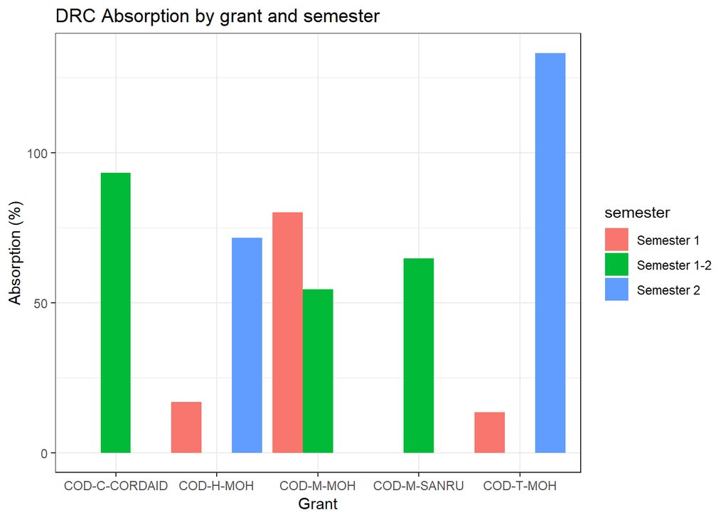

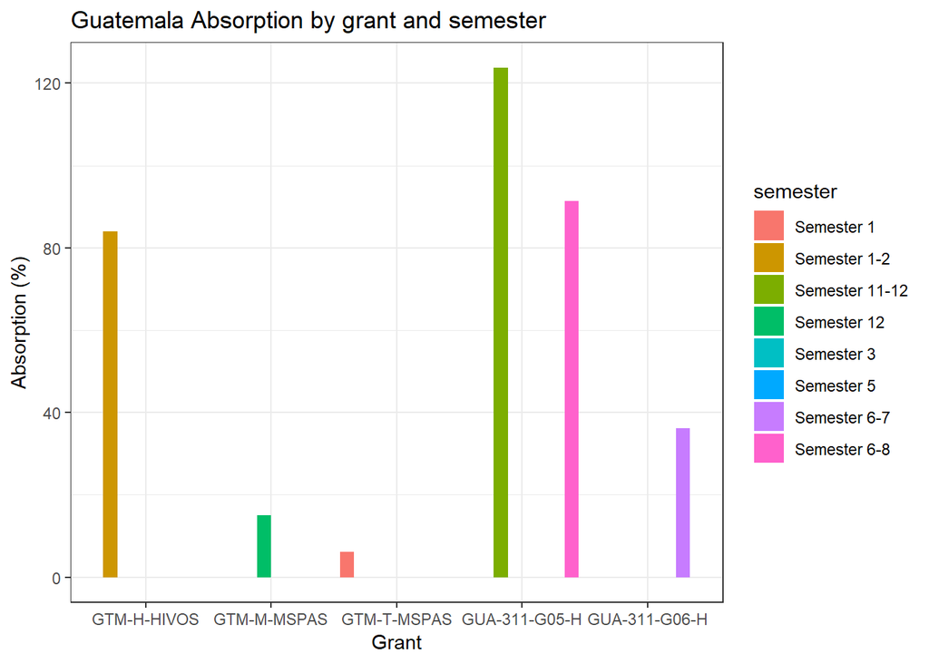

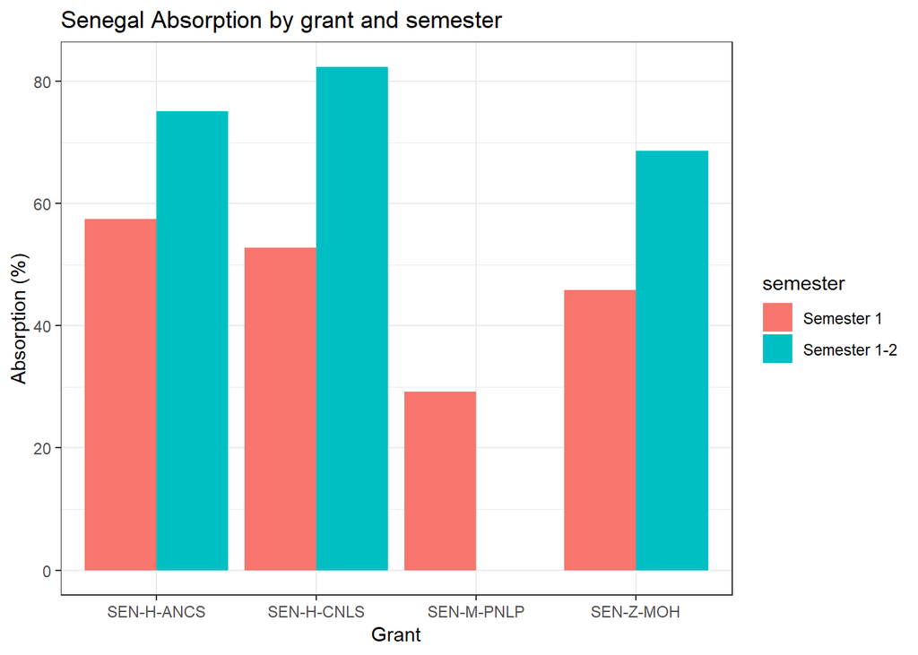

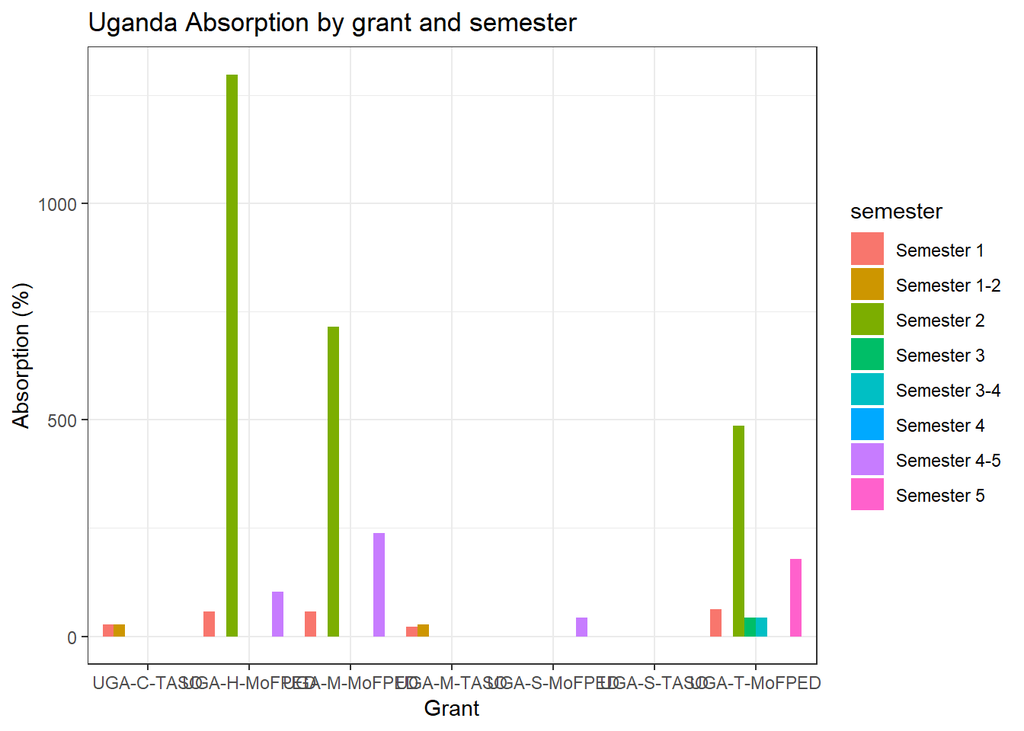